# Review of SNAPPER results

J. Ignacio Lucas Lledó

2026-03-10

The fact that SNAPPER’s Path Sampler yielded a Bayes factor supporting the existence of only one species made no sense in face of the clear distinction of the two lineages. I suspected a mistake must have been introduced somewhere in the process.

## Original Path-sampler results

The path sampler with 8 steps produced the following outputs, which were copied from `/nata/mar/crepidostomum2/results/2025-05-22/ML_chains.txt` in February 2026:

[output not shown]

I manually save the output of individual runs in separate files to look at them in R. There are also a couple complete runs of the path sampler with 48 steps, where hybrids were included. They are also copied to text files here, for easy upload in R.

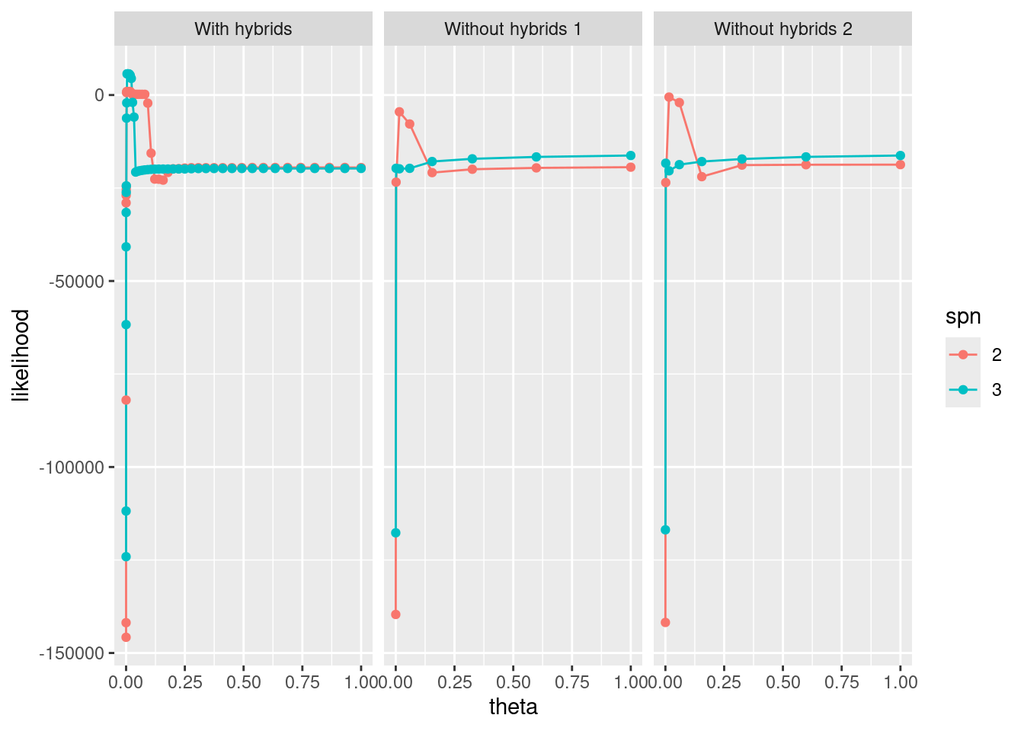

```r
library(ggplot2)
c2.1 <- read.table('cp2.1.txt', header = TRUE)
c2.1$spn <- 2
c2.1$run <- 'Without hybrids 1'
c2.2 <- read.table('cp2.2.txt', header = TRUE)
c2.2$spn <- 2
c2.2$run <- 'Without hybrids 2'
c2.3 <- read.table('cp2.3.txt', header = TRUE)
c2.3$spn <- 2
c2.3$run <- 'With hybrids'
c3.1 <- read.table('cp3.1.txt', header = TRUE)
c3.1$spn <- 3
c3.1$run <- 'Without hybrids 1'
c3.2 <- read.table('cp3.2.txt', header = TRUE)
c3.2$spn <- 3
c3.2$run <- 'Without hybrids 2'
c3.3 <- read.table('cp3.3.txt', header = TRUE)
c3.3$spn <- 3
c3.3$run <- 'With hybrids'
paths <- rbind(c2.1, c2.2, c2.3, c3.1, c3.2, c3.3)
paths$spn <- factor(paths$spn)
ggplot(paths, aes(x = theta, y = likelihood, color = spn)) +
   geom_line() + geom_point() + facet_wrap(~run)
```

```r
sapply(split(paths$contribution, list(paths$spn, paths$run)), sum)
```

```
##      2.With hybrids      3.With hybrids 2.Without hybrids 1 3.Without hybrids 1
##           -17391.65           -18949.70           -17284.12           -17152.79
## 2.Without hybrids 2 3.Without hybrids 2
##           -16891.47           -17068.24
```

The reason why the marginal likelihood is higher in the models of two species than in the models with three species (which is not always the case, by the way) is the bump at low values of theta, which I think represent distributions closer to the prior than to the posterior. Let’s take a look at the Markov chains. Apparently, the chains were run for 10 million generations and sampled every 1000 generations. They include the burn-in. Mean log-likelihood at each step must have been calculated after excluding a burn-in. The burn-in can be specified when launching the `PathSampleAnalyser` application. In some cases, 10% seem insufficient. Let’s see:

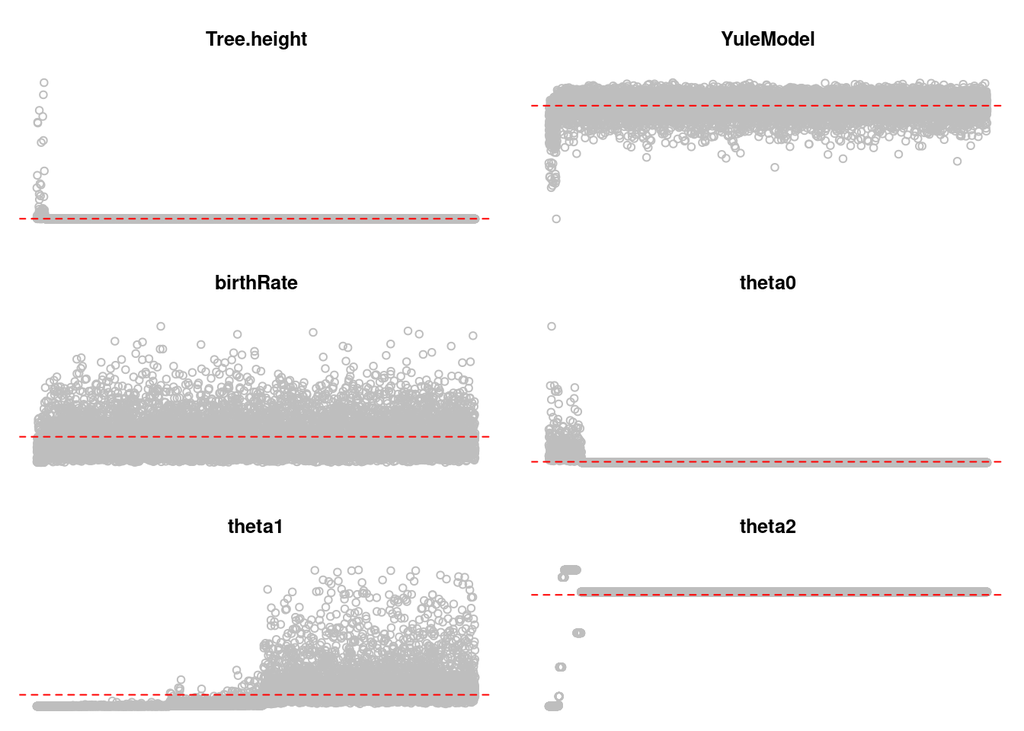

```r
source('mcmc.R')
burninpercent <- 10
folder <- '/nata/mar/crepidostomum2/results/2025-05-22/no_hybrids/'
mcmc1 <- lapply(paste0(folder, 'ref_c2sp_first/steps/step', 0:7, '/ref_cp2_first.log'),
                read.table, header = TRUE)
mcmc2 <- lapply(paste0(folder, 'ref_c2sp_second/steps/step', 0:7, '/ref_cp2_second.log'),
                read.table, header = TRUE)
mcmc1 <- lapply(mcmc1,
                function(x) {
                   r <- nrow(x)
                   minr <- round(r * burninpercent / 100)
                   return(x[minr:r,])
                })
mcmc2 <- lapply(mcmc2,
                function(x) {
                   r <- nrow(x)
                   minr <- round(r * burninpercent / 100)
                   return(x[minr:r,])
                })
tendencyPlot(mcmc1[[5]][, -c(2,3,4,6,7,8,9)])
```

Steps of the Path Sampler are numbered from zero, starting from the highest value of theta (1.0). Thus, the fifth element of the `mcmc1` list is actually step numbered “4”, which is the one with the fifth highest value of theta (or the fourth lowest one, since there are 8 steps). It is the only step in this series where the MCMC took longer to converge than the specified burn-in. But it’s not the only step where the average log-likelihood goes higher than expected. In the second run, there are two steps where convergence happened after the burn-in.

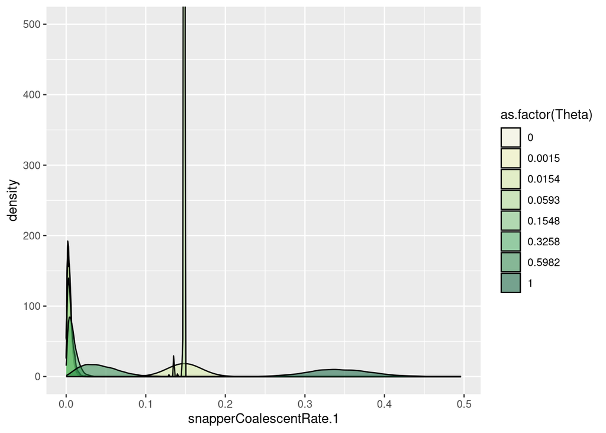

```r
for (i in 1:8) {
   Step <- i - 1
   mcmc1[[i]]$Step  <- Step
   mcmc1[[i]]$Theta <- paths[paths$spn == 2 &
                             paths$run == 'Without hybrids 1' &
                             paths$Step == Step, 'theta']
   mcmc2[[i]]$Step  <- Step
   mcmc2[[i]]$Theta <- paths[paths$spn == 2 &
                             paths$run == 'Without hybrids 2' &
                             paths$Step == Step, 'theta']
}
mc1 <- do.call(rbind, mcmc1)
mc2 <- do.call(rbind, mcmc2)
mc1$Step <- factor(mc1$Step)
mc2$Step <- factor(mc2$Step)
ggplot(mc1, aes(x = snapperCoalescentRate.1, fill = as.factor(Theta))) +
   geom_density(alpha = 0.5) + scale_fill_brewer(palette = 'YlGn') +
   coord_cartesian(ylim = c(0, 500))
```

The plot above illustrates that the distributions of some parameters do not transit smoothly between the prior and the posterior. The likelihoods along the path also adopt erratically different distributions. The whole point of the path sampling is to get a series of similar distributions that go smoothly between the prior and the posterior. See [this post by Darren Wilkinson](https://darrenjw.wordpress.com/2013/10/01/marginal-likelihood-from-tempered-bayesian-posteriors/).

# Check the data

For some reason it’s difficult to read the Nexus file directly. Let’s implement our own reader.

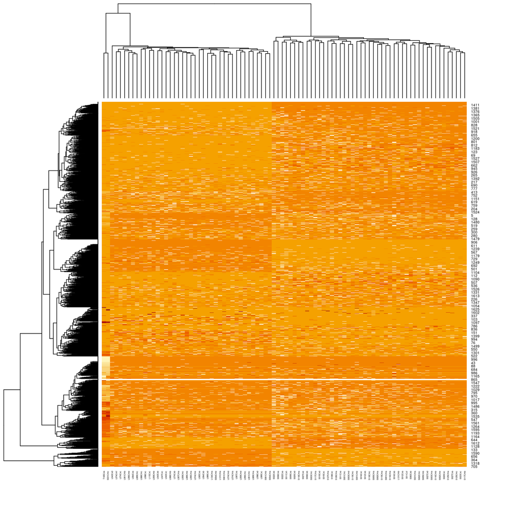

```r
toRef <- readLines('../2025-03-15/toRef.nex')
# Assuming the longest lines contain the matrix of genotypes
l <- max(nchar(toRef))
toRef <- toRef[nchar(toRef) == l]
z <- unlist(strsplit(toRef, ' '))
snps <- z[1:length(z) %% 2 == 0]
names(snps) <- z[1:length(z) %% 2 == 1]
snps <- strsplit(snps, '')
snps <- lapply(snps, function(x) {x[x == '-'] <- NA; return(as.numeric(x))})
m <- do.call(cbind, snps)
heatmap(m, cexCol = 0.3)
```

Now the genotypes matrix looks ok. But when I first looked into it, I realized there were a lot of invariable sites. There was an error in `2025-03-15`, which has already been corrected. Hopefully, this will solve the contradictory results. New MCMC are already running to estimate again the Bayes factor. Let’s see.

# Let’s check the new path sampling process

Below I animate the series of tendency plots. I ignore some parameters: the tree length is redundant with the tree height, and coalescent rates are twice the inverse of theta parameters.

```r
ref2sp <- '/nata/mar/crepidostomum2/results/2025-05-22/new_executions/ref_c2sp_first/steps/step'
ref3sp <- '/nata/mar/crepidostomum2/results/2025-05-22/new_executions/ref_c3sp_first/steps/step'
log2sp <- lapply(paste0(ref2sp, 0:47, '/ref_c2sp.log'),
                 function(x) {
                    if (file.exists(x)) read.table(x, header = TRUE)})
log3sp <- lapply(paste0(ref3sp, 0:47, '/ref_c3sp.log'),
                 function(x) {
                    if (file.exists(x)) read.table(x, header = TRUE)})
log2sp <- log2sp[! sapply(log2sp, is.null)]
log3sp <- log3sp[! sapply(log3sp, is.null)]
if (! dir.exists('c2sp')) dir.create('c2sp')
if (! dir.exists('c3sp')) dir.create('c3sp')
devnull <- lapply(seq_along(log2sp),
                  function(x) {
                     png(filename = sprintf('c2sp/tendency%02i.png', x))
                     tendencyPlot(log2sp[[x]][, -c(2,3,4,6,7,8,9)])
                     dev.off()
                  })
devnull <- lapply(seq_along(log3sp),
                  function(x) {
                     png(filename = sprintf('c3sp/tendency%02i.png', x))
                     tendencyPlot(log3sp[[x]][, -c(2,3,4,6,7,8,9,10,11)])
                     dev.off()
                  })
```

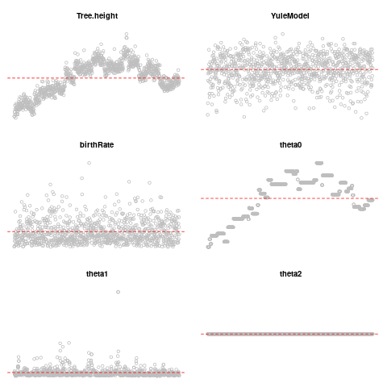

```bash
if [[ ! -e path2sp.gif && -e c2sp/tendency01.png ]]; then
   convert -delay 100 -loop 0 c2sp/*.png path2sp.gif
fi

if [[ ! -e path3sp.gif && -e c3sp/tendency01.png ]]; then
   convert -delay 100 -loop 0 c3sp/*.png path3sp.gif
fi
```

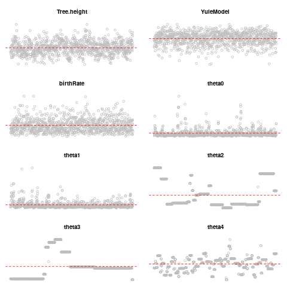